# 📊 Amazon Sales Report - Data Analysis & Business Insights

# VISUALIZATIONS

## Chart 1: Top 10 Categories by Quantity Sold

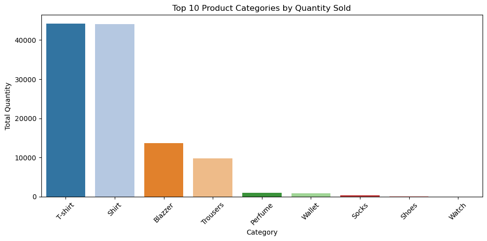

```python
plt.figure(figsize=(10, 5))
sns.barplot(x=top_qty_categories.index, y=top_qty_categories.values, palette='tab20')
plt.title("Top 10 Product Categories by Quantity Sold")
plt.xlabel("Category")
plt.ylabel("Total Quantity")
plt.xticks(rotation=45)
plt.tight_layout()
plt.show()
```

## Chart 2: Top 10 Categories by Sales

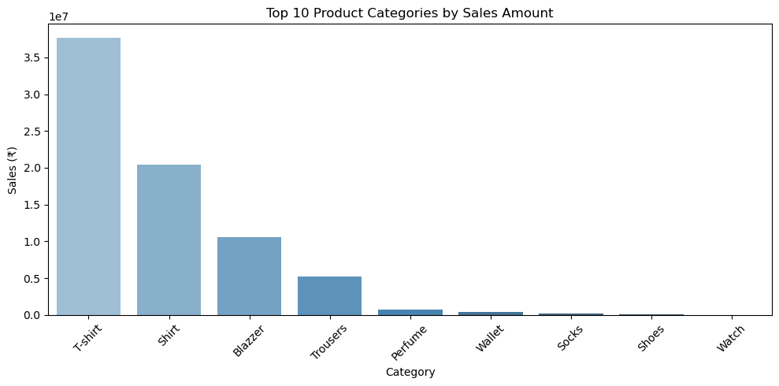

```python
plt.figure(figsize=(10, 5))
sns.barplot(x=top_revenue_categories.index, y=top_revenue_categories.values, palette='Blues_d')
plt.title("Top 10 Product Categories by Sales Amount")
plt.xlabel("Category")
plt.ylabel("Sales (₹)")
plt.xticks(rotation=45)
plt.tight_layout()
plt.show()
```

## Chart 3: Most Popular Sizes

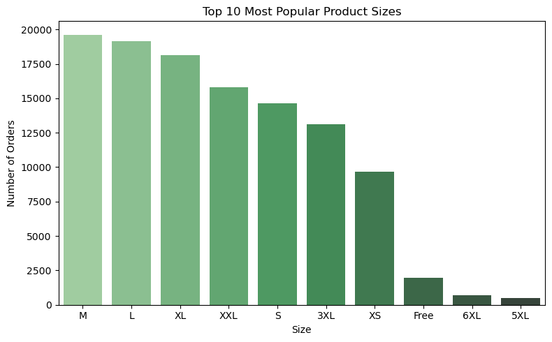

```python
plt.figure(figsize=(8, 5))
sns.barplot(x=top_sizes.index, y=top_sizes.values, palette='Greens_d')
plt.title("Top 10 Most Popular Product Sizes")
plt.xlabel("Size")
plt.ylabel("Number of Orders")
plt.tight_layout()
plt.show()
```

## Chart 4: Top 5 Product Categories by Quantity

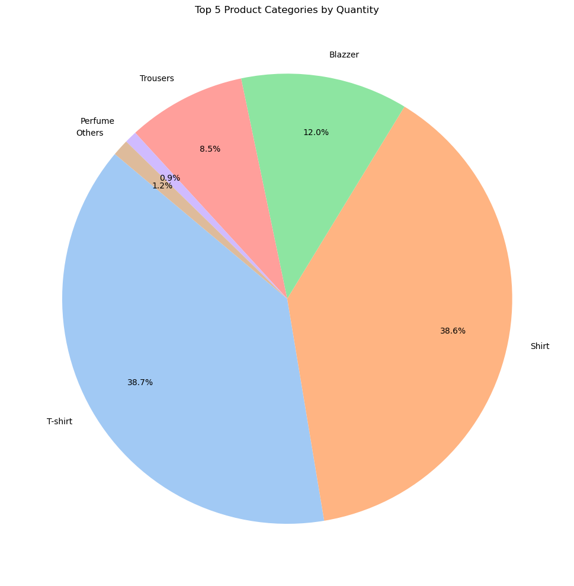

```python
# Top 5 categories by quantity
top5_qty = top_qty_categories.head(5)
others_qty = top_qty_categories.iloc[5:].sum()
final_qty = pd.concat([top5_qty, pd.Series({'Others': others_qty})])

# Plot
plt.figure(figsize=(10, 10))
plt.pie(
    final_qty,
    labels=final_qty.index,
    autopct='%1.1f%%',
    startangle=140,
    textprops={'fontsize': 10},
    labeldistance=1.1,
    pctdistance=0.75,
    colors=sns.color_palette("pastel")[0:len(final_qty)]
)
plt.title("Top 5 Product Categories by Quantity")
plt.tight_layout()
plt.show()
```

## Chart 5: Top 5 Product Categories by Sales

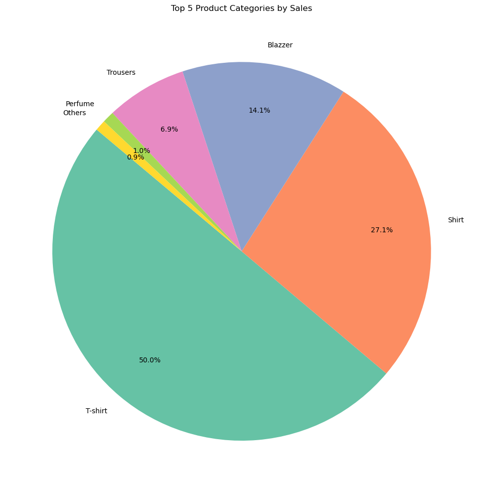

```python
# Top 5 categories by sales
top5_sales = top_revenue_categories.head(5)
others_sales = top_revenue_categories.iloc[5:].sum()
final_sales = pd.concat([top5_sales, pd.Series({'Others': others_sales})])

# Pie chart
plt.figure(figsize=(10, 10))
plt.pie(
    final_sales,
    labels=final_sales.index,
    autopct='%1.1f%%',
    startangle=140,
    textprops={'fontsize': 10},
    labeldistance=1.1,
    pctdistance=0.75,
    colors=sns.color_palette("Set2")
)

plt.title("Top 5 Product Categories by Sales")
plt.tight_layout()
plt.show()
```

# ✅ Conclusion

- 📦 A few product categories contribute the most to both sales and quantity.
- 🥇 The top 5 categories generated over 75% of the total revenue.
- 📉 Many other categories have very low contribution — may need better marketing or bundling.
- 🎯 Focusing efforts on high-performing categories while exploring potential in low-performing ones can increase sales.

# **TASK-03**

# Fulfilment Analysis:

Investigate the fulfillment methods used and their effectiveness in delivering orders.

## Step 1: Unique Fulfillment Methods in Dataset

```python
# View unique fulfillment types
valid_sales['Fulfilment'].unique()
```

```
array(['Merchant', 'Amazon'], dtype=object)
```

## Step 2: Number of Orders by Fulfillment Method

```python
# Count orders by fulfillment method
fulfillment_counts = valid_sales['Fulfilment'].value_counts()

print("🚚 Total Orders by Fulfillment Type:")
print(fulfillment_counts)
```

```
🚚 Total Orders by Fulfillment Type:
Fulfilment
Amazon      82121
Merchant    31578
Name: count, dtype: int64
```

## Step 3: Sales, Quantity, Orders, Avg_Order_Value Summary

```python
# Group by fulfillment and calculate total sales, qty, orders, avg order value
fulfillment_summary = valid_sales.groupby('Fulfilment').agg(
    Total_Orders=('Order ID', 'nunique'),
    Total_Qty=('Qty', 'sum'),
    Total_Sales=('Amount', 'sum')
)
fulfillment_summary['Avg_Order_Value'] = fulfillment_summary['Total_Sales'] / fulfillment_summary['Total_Orders']
fulfillment_summary = fulfillment_summary.sort_values(by='Total_Sales', ascending=False)

print("📦 Fulfillment Performance Summary:")
print(fulfillment_summary)
```

```
📦 Fulfillment Performance Summary:
            Total_Orders  Total_Qty  Total_Sales  Avg_Order_Value
Fulfilment
Amazon             76684      82402   54327540.0       708.459913
Merchant           29135      31734   21072777.0       723.280487
```

## Step 4: Order Status by Fulfillment Method

```python
status_fulfillment = valid_sales.groupby(['Fulfilment', 'Status']).size().unstack().fillna(0)

print("📦 Order Status by Fulfillment Method:")
print(status_fulfillment)
```

```
📦 Order Status by Fulfillment Method:
Status      Cancelled  Pending  Pending - Waiting for Pick Up  Shipped  \
Fulfilment
Amazon         5629.0    404.0                            0.0  76088.0
Merchant          0.0    235.0                          272.0      0.0

Status      Shipped - Damaged  Shipped - Delivered to Buyer  \
Fulfilment
Amazon                    0.0                           0.0
Merchant                  1.0                       28033.0

Status      Shipped - Lost in Transit  Shipped - Out for Delivery  \
Fulfilment
Amazon                            0.0                         0.0
Merchant                          3.0                        35.0

Status      Shipped - Picked Up  Shipped - Rejected by Buyer  \
Fulfilment
Amazon                      0.0                          0.0
Merchant                  945.0                         11.0

Status      Shipped - Returned to Seller  Shipped - Returning to Seller
Fulfilment
Amazon                               0.0                            0.0
Merchant                          1900.0                          143.0
```

## Step 4: Order Status Breakdown by Fulfillment Method

```python
# Safe Step 4: Auto-selects available columns, no KeyError

# Add Total column
status_fulfillment['Total'] = status_fulfillment.sum(axis=1)

# Auto-detect correct delivery & return columns
success_col = 'Shipped - Delivered to Buyer'  # use the exact name from your output
return_col = 'Shipped - Returned to Seller'

# Add metrics
status_fulfillment['Return %'] = (status_fulfillment.get(return_col, 0) / status_fulfillment['Total']) * 100
status_fulfillment['Success %'] = (status_fulfillment.get(success_col, 0) / status_fulfillment['Total']) * 100

# Show only columns that exist
columns_to_show = [col for col in [success_col, return_col, 'Total', 'Return %', 'Success %'] if col in status_fulfillment.columns]

# Final display
print("📊 Status Breakdown by Fulfillment:")
print(status_fulfillment[columns_to_show])
```

```
📊 Status Breakdown by Fulfillment:
Status      Shipped - Delivered to Buyer  Shipped - Returned to Seller  \
Fulfilment
Amazon                               0.0                           0.0
Merchant                         28033.0                        1900.0

Status        Total  Return %  Success %
Fulfilment
Amazon      82121.0  0.000000    0.00000
Merchant    31578.0  6.016847   88.77383
```

# VISUALIZATIONS

## Chart 1: Total Orders by Fulfillment

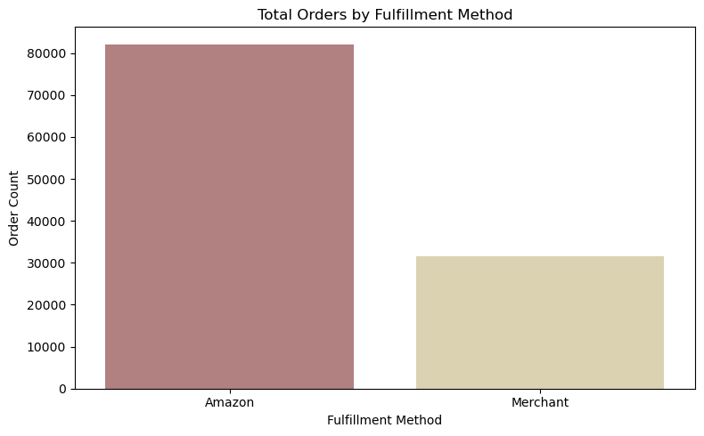

```python
plt.figure(figsize=(8, 5))
sns.barplot(x=fulfillment_counts.index, y=fulfillment_counts.values, palette='pink')
plt.title("Total Orders by Fulfillment Method")
plt.xlabel("Fulfillment Method")
plt.ylabel("Order Count")
plt.tight_layout()
plt.show()
```

## Chart 2: Total Sales by Fulfillment

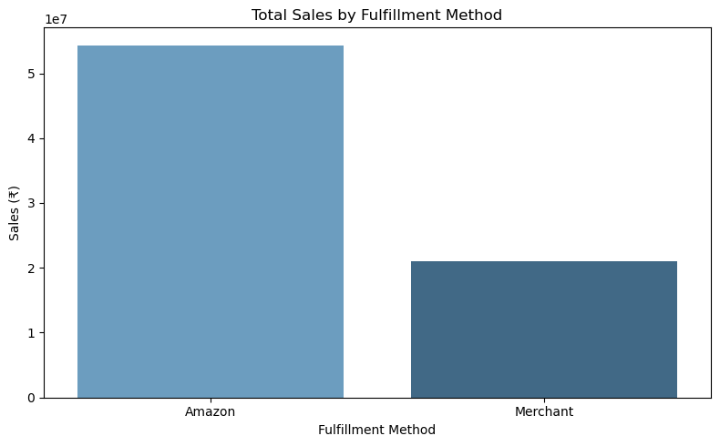

```python
plt.figure(figsize=(8, 5))
sns.barplot(x=fulfillment_summary.index, y=fulfillment_summary['Total_Sales'], palette='Blues_d')
plt.title("Total Sales by Fulfillment Method")
plt.xlabel("Fulfillment Method")
plt.ylabel("Sales (₹)")
plt.tight_layout()
plt.show()
```

## Chart 3: Average Order Value

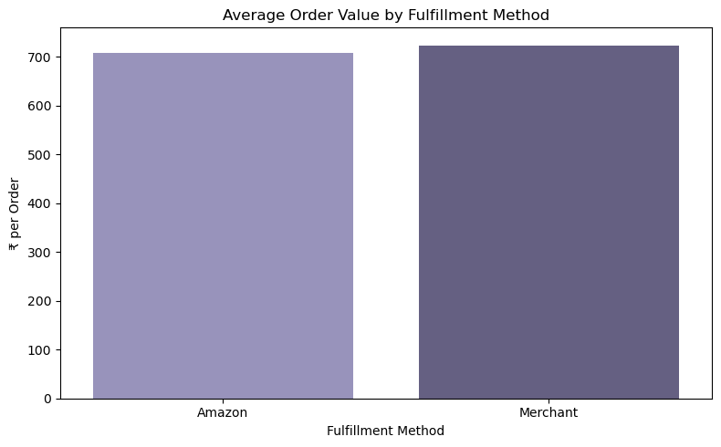

```python
plt.figure(figsize=(8, 5))
sns.barplot(x=fulfillment_summary.index, y=fulfillment_summary['Avg_Order_Value'], palette='Purples_d')
plt.title("Average Order Value by Fulfillment Method")
plt.xlabel("Fulfillment Method")
plt.ylabel("₹ per Order")
plt.tight_layout()
plt.show()
```